# Set Shots in Australian Football: Geometry, Stan, and Student’s $t$

Goals, Behinds, and Posteriors (sorry, I couldn’t help it)

James R Bland (https://sites.google.com/site/jamesbland/)

December 12, 2019

In a great example of it never hurting to ask about sharing data, a few weeks ago I asked https://www.statsinsider.com.au/ whether they would be willing to share their shot location data from the men’s [Australian Football League (AFL)](https://www.afl.com.au/). So now I have 20,647 shots on goal from the 2018 and 2019 AFL seasons.

For those of you unfamiliar with Australian football, here is a very detailed introduction.

[video not shown]

The bit you need to know for this post is the following: Teams in Australian football score points by kicking (“punting” in American Football language) the ball between upright posts. There are four upright posts at each end of the field. Kick the ball between the middle two for a goal (six points), or between the others for a “behind” (one point). Here are some example of goals:

[video not shown]

For this post, I will be focused on “set shots” on goal, which occur when a player catches a kicked ball before it touches the ground (called a “mark”), or there is some kind of foul by the other team (e.g. an illegal tackle). Here is an example of a mark followed by a set shot:

[video not shown]

That was [Sav Rocca](https://en.wikipedia.org/wiki/Sav_Rocca) playing for the Collingwood Magpies. Unsurprisingly, he retired from the Australian Football League to punt in the NFL (2007-2013).

For more context, here are some more examples of marks:

[video not shown]

And a little bit more about set shots:

[video not shown]

Set shots in Australian football can be seen as an extension of [how I thought about NFL field goal attempts](https://jamesblandecon.github.io/NFLFieldGoals.html) in the following ways:

- The attempt is made from where the mark is taken, so I have meaningful variation in both distance and angle (whereas for my NFL application, I only had information on distance).
- With the dataset I have, I have more information on the result of the set shot. Namely the data categorizes each attempt into things like “goal”, missed by a bit (a “behind”), missed by a lot (“Miss, out of bounds”), and “Didn’t make the distance”.

## Data and model

Here are the data from the 9,910 set shots in the 2018 and 2019 AFL seasons. They are coarsened in that the distance to the center of the goal is given in increments of 5m, and the angle is given to the nearest 5 degrees. “Value” here measures the average score (6, 1, or 0) for each of these bins. I am going to assume for simplicity that the shots are taken from exactly these points. Later I might relax this assumption.

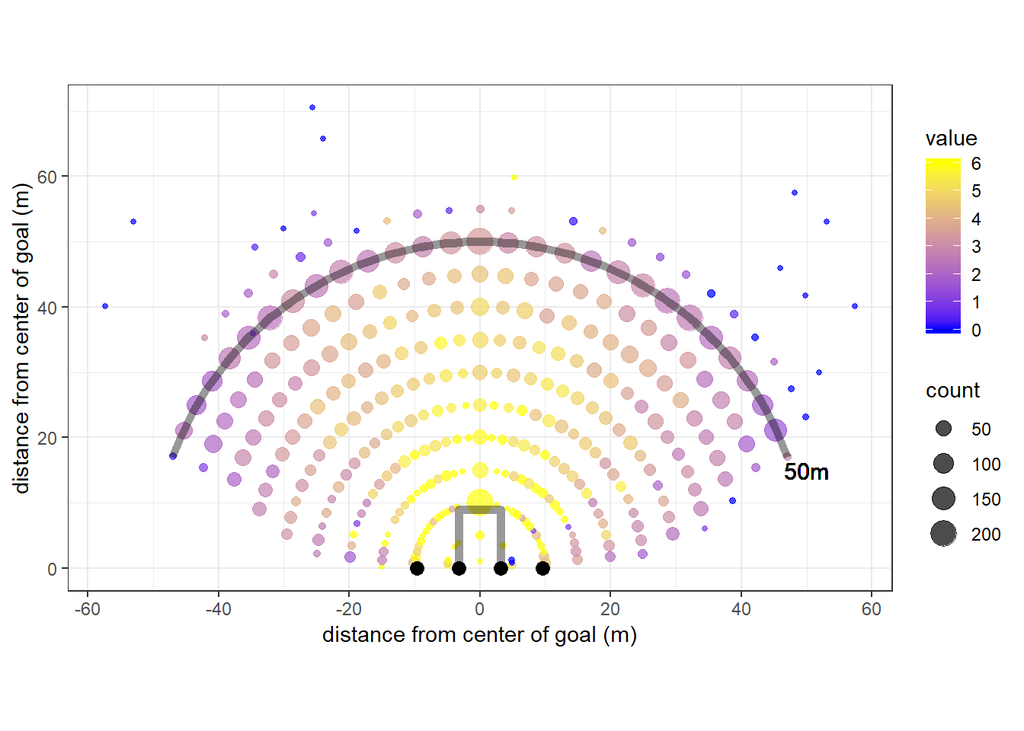

As with the NFL field goals model, I will assume that a player kicking from point $x$ aims directly between the middle of the goalposts (point X on the diagram below), and has random, symmetric, mean-zero angle error $\theta$. However, unlike my NFL application, assuming a mean-zero normal distribution for this has resulted in Stan’s dreaded “divergent transitions” warning message on too many attempts for it to be worth my time trying to fix it. After much weeping and gnashing of teeth, I finally decided to try a Student’s $t$ distribution, and it worked great. Not only that, but it was pretty easy to see why the normal wasn’t working. Hence, I assume that:
$$\theta/\kappa\sim\mathrm{t}(\nu)$$

From here, I need to map coordinates $x$ and parameters $\kappa$ and $\nu$ into probabilities of kicking through the blue region (a goal, 6 points), one of the red regions (a behind, 1 point), or anything else (zero points).

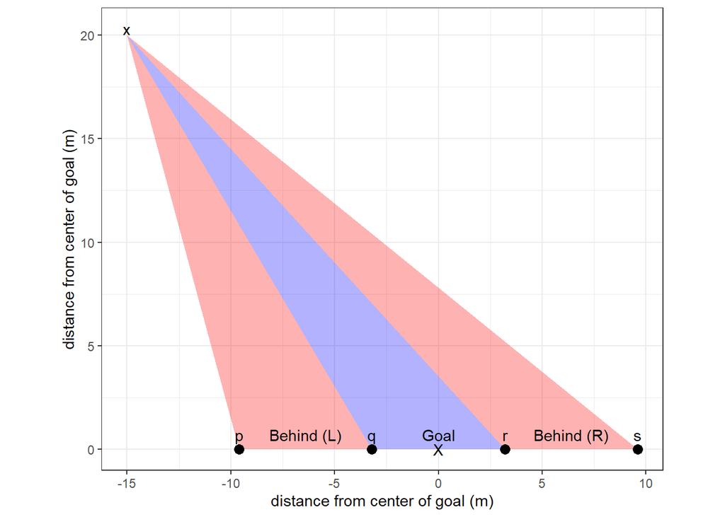

I assume that everything not resulting in a goal or a behind is a miss. I actually have quite a bit of information about misses, but that will be added in another post.

```r
  unique(D$`Shot result`)
```

```
## [1] "Goal"                 "Behind"               "Didn't make distance"
## [4] "Miss, out of bounds"  "Miss, in play"        "Touched"
## [7] "Free kick mid-shot"
```

## Estimating the model in Stan

```c
// saved as AFLAngleTcount.stan
data {
  vector[2] priork;
  vector[2] priornu;
  int n;
  vector[n] goal;
  vector[n] behind;
  vector[n] other;
  vector[n] aGoal;
  vector[n] aLBehind;
  vector[n] aRBehind;
}
transformed data {
    vector[n] ones;
    for (ii in 1:n) {
        ones[ii] = 1;
    }
}
parameters {
  real<lower=0> k;
  real<lower=0> nu;
}
transformed parameters {

}
model {
    vector[n] pGoal;
    vector[n] pLBehind;
    vector[n] pRBehind;


    // prior
    k ~ lognormal(priork[1],priork[2]);
    nu ~ lognormal(priornu[1],priornu[2]);



    // student_t_cdf(reals y, reals nu, reals mu, reals sigma)
    for (ii in 1:n) {
        pGoal[ii]       = student_t_cdf(aGoal[ii] / (2.0),nu,0.0,k)-student_t_cdf(-aGoal[ii] / (2.0),nu,0.0,k);
        pLBehind[ii]    = student_t_cdf(-aGoal[ii]/(2.0),nu,0.0,k)-student_t_cdf(-aGoal[ii]/(2.0)-aLBehind[ii],nu,0.0,k);
        pRBehind[ii]    = student_t_cdf(aRBehind[ii]+aGoal[ii]/(2.0),nu,0.0,k)-student_t_cdf(aGoal[ii]/(2.0),nu,0.0,k);
    }

    // model with just goals
    //target += goal .* log(pGoal) + (behind + other) .* log(1.0-pGoal);

    // likelihood contribution for goals
    target += goal .* log(pGoal);
    // likelihood contribution for behinds
    target += behind .* log(pLBehind+pRBehind);
    // likelihood contribution for everything else
    target += other .* log(1.0-pGoal-pLBehind-pRBehind);
}

generated quantities {
    real pGoal50;
    pGoal50 = student_t_cdf(0.1278257 / (2.0),nu,0.0,k)-student_t_cdf(-0.1278257 / (2.0),nu,0.0,k);
}
```

## Results

Here is the output from RStan:

```
## Inference for Stan model: AFLAngleTcount.
## 4 chains, each with iter=2000; warmup=1000; thin=1;
## post-warmup draws per chain=1000, total post-warmup draws=4000.
##
##             mean se_mean   sd     2.5%      25%      50%      75%    97.5%
## k           0.08    0.00 0.00     0.07     0.07     0.08     0.08     0.08
## nu          2.60    0.00 0.15     2.32     2.50     2.59     2.69     2.90
## pGoal50     0.53    0.00 0.01     0.52     0.53     0.53     0.54     0.54
## lp__    -8946.49    0.03 1.05 -8949.26 -8946.87 -8946.16 -8945.75 -8945.49
##         n_eff Rhat
## k        1191    1
## nu       1148    1
## pGoal50  1712    1
## lp__     1018    1
##
## Samples were drawn using NUTS(diag_e) at Thu Dec 12 14:28:04 2019.
## For each parameter, n_eff is a crude measure of effective sample size,
## and Rhat is the potential scale reduction factor on split chains (at
## convergence, Rhat=1).
```

So why was the normal distribution causing me so much grief? One reason could be that here I have estimated $\nu=2.6$. For $\nu\approx 30$ or greater, there isn’t much difference between a normal and Student’s $t$ distribution, but for lower values, they are quite different: $t$ has fatter tails. Holding the probability of a goal constant, the model with normal errors was probably understating the probability of a miss (and hence overstating the probability of a behind).

Here is the posterior density for the standard deviation in angle accuracy, which is equal to $\kappa\sqrt{\frac{\nu}{\nu-2}}\frac{180}{\pi}^\circ$.

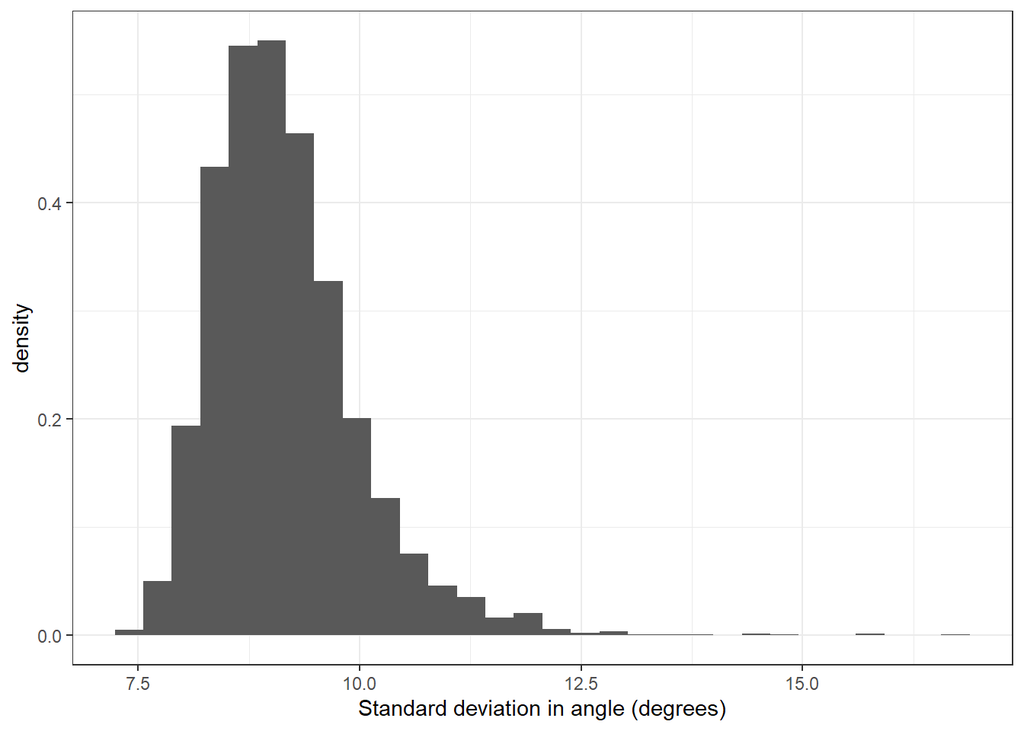

Here is the same plot of the data from above, superimposed over the model’s predictions (posterior mean):

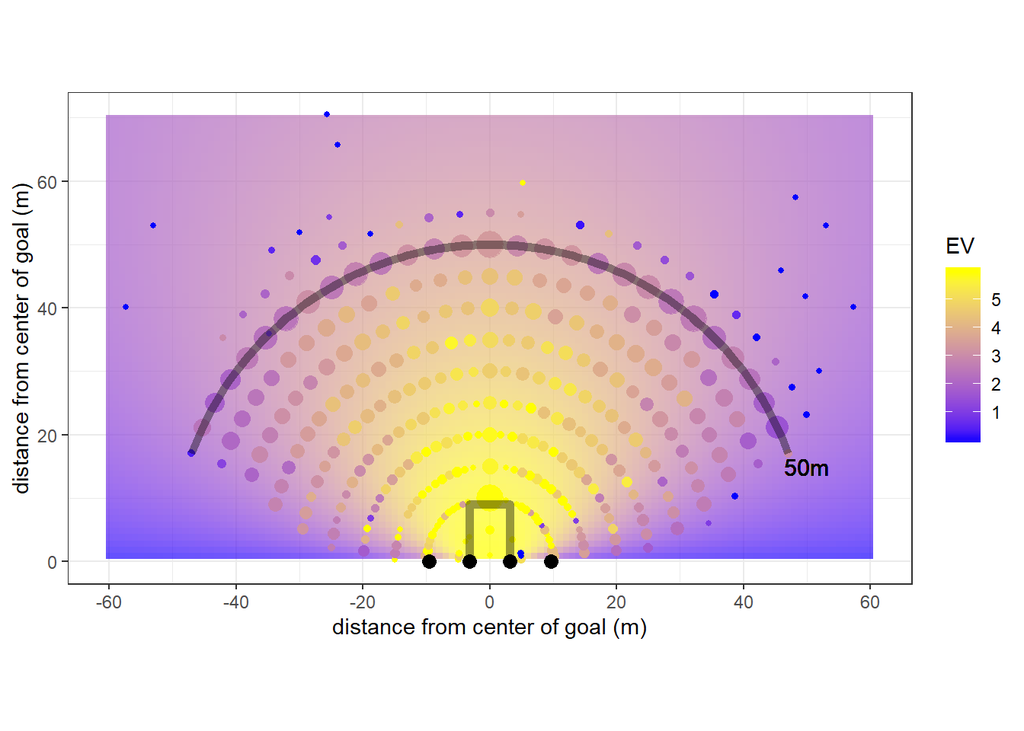

“EV” is the expected value (goal=6, behind=1, other=0) of a set shot from that position. When the dots (data) are the same color as the background image (predictions), the model and data are fitting well.

This next plot breaks down the model’s predictions by angle ($0^\circ$ is directly in front of goal). Generally, is is doing well for smaller angles and distances of about 40m or less.

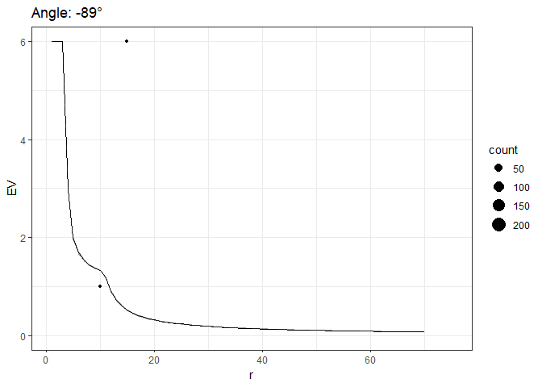

Another way to visualize the model’s fit is by plotting predictions (horizontal axis) against the binned means of these events (vertical axis). If dots lie on the $45^\circ$ line, then the model is predicting well (within-sample, at least). This seems to be mostly true for the purple-blue dots, which are angles with absolute value less than about $40^\circ$.

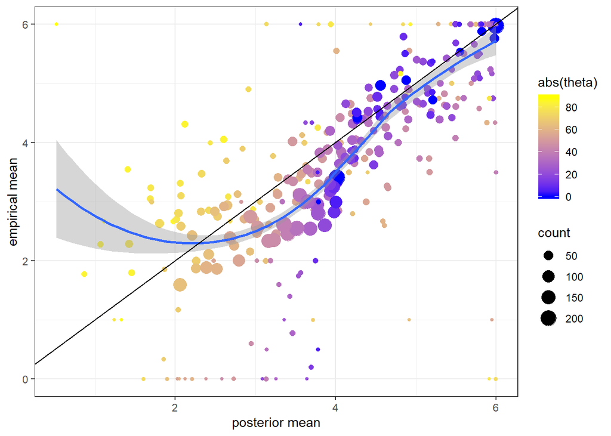

I will finish up here for now, but there’s a lot more I can do with these data. Watch this space, and thanks to https://www.statsinsider.com.au/ for putting together and sharing such an amazing dataset!

[See more coding examples here](https://sites.google.com/site/jamesbland/code-examples)